# Tables and Models formatting

Chathurangi Pathiravasan

11/19/2020

# Tables formatting in R: the tableone package

Before you apply any of these functions please convert categorical variables to factor variables and specify reference group clearly.

## What is tableone

The tableone package is an R package that eases the construction of “Table 1”, i.e., patient baseline characteristics table commonly found in biomedical research papers. The packages can summarize both continuous and categorical variables mixed within one table. Categorical variables can be summarized as counts and/or percentages. Continuous variables can be summarized in the “normal” way (means and standard deviations) or “nonnormal” way (medians and interquartile ranges).

```r
## tableone package itself
library(tableone)

## survival package for Mayo Clinic's PBC data
library(survival)
data(pbc)
CreateTableOne(data = pbc)
```

```
##
##                        Overall
##   n                        418
##   id (mean (SD))        209.50 (120.81)
##   time (mean (SD))     1917.78 (1104.67)
##   status (mean (SD))      0.83 (0.96)
##   trt (mean (SD))         1.49 (0.50)
##   age (mean (SD))        50.74 (10.45)
##   sex = f (%)              374 (89.5)
##   ascites (mean (SD))     0.08 (0.27)
##   hepato (mean (SD))      0.51 (0.50)
##   spiders (mean (SD))     0.29 (0.45)
##   edema (mean (SD))       0.10 (0.25)
##   bili (mean (SD))        3.22 (4.41)
##   chol (mean (SD))      369.51 (231.94)
##   albumin (mean (SD))     3.50 (0.42)
##   copper (mean (SD))     97.65 (85.61)
##   alk.phos (mean (SD)) 1982.66 (2140.39)
##   ast (mean (SD))       122.56 (56.70)
##   trig (mean (SD))      124.70 (65.15)
##   platelet (mean (SD))  257.02 (98.33)
##   protime (mean (SD))    10.73 (1.02)
##   stage (mean (SD))       3.02 (0.88)
```

## Categorical variable conversion?

Most of the categorical variables are coded numerically, so we either have to transform them to factors in the dataset or use factorVars argument to transform them on-the-fly. Also it’s a better practice to specify which variables to summarize by the vars argument, and exclude the ID variable(s). How do we know which ones are numerically-coded categorical variables? Please check your data dictionary (in this case help(pbc)). This time I am saving the result object in a variable. It’s more interpretable now. Binary categorical variables are summarized as counts and percentages of the second level. For example, if it is coded as 0 and 1, the “1” level is summarized. For 3+ category variable all levels are summarized. Please bear in mind, the percentages are calculated after excluding missing values. If you want to show all levels, you can use showAllLevels argument to the print() method.

```r
## Vector of variables to summarize
myVars <- c("time", "status", "trt", "age", "sex", "ascites", "hepato",
          "spiders", "edema", "bili", "chol", "albumin", "copper", "alk.phos",
          "ast", "trig", "platelet", "protime", "stage")
## Vector of categorical variables that need transformation
catVars <- c("status", "trt", "ascites", "hepato",
             "spiders", "edema", "stage")
## Create a TableOne object
tab2 <- CreateTableOne(vars = myVars, data = pbc, factorVars = catVars)
tab2
```

```
##
##                        Overall
##   n                        418
##   time (mean (SD))     1917.78 (1104.67)
##   status (%)
##      0                     232 (55.5)
##      1                      25 ( 6.0)
##      2                     161 (38.5)
##   trt = 2 (%)              154 (49.4)
##   age (mean (SD))        50.74 (10.45)
##   sex = f (%)              374 (89.5)
##   ascites = 1 (%)           24 ( 7.7)
##   hepato = 1 (%)           160 (51.3)
##   spiders = 1 (%)           90 (28.8)
##   edema (%)
##      0                     354 (84.7)
##      0.5                    44 (10.5)
##      1                      20 ( 4.8)
##   bili (mean (SD))        3.22 (4.41)
##   chol (mean (SD))      369.51 (231.94)
##   albumin (mean (SD))     3.50 (0.42)
##   copper (mean (SD))     97.65 (85.61)
##   alk.phos (mean (SD)) 1982.66 (2140.39)
##   ast (mean (SD))       122.56 (56.70)
##   trig (mean (SD))      124.70 (65.15)
##   platelet (mean (SD))  257.02 (98.33)
##   protime (mean (SD))    10.73 (1.02)
##   stage (%)
##      1                      21 ( 5.1)
##      2                      92 (22.3)
##      3                     155 (37.6)
##      4                     144 (35.0)
```

```r
#print(tab2, showAllLevels = TRUE, formatOptions = list(big.mark = ","))


#Detailed information including missingness
#summary(tab2)


#Summarizing nonnormal variables
#biomarkers <- c("bili","chol","copper","alk.phos","ast","trig","protime")
#print(tab2, nonnormal = biomarkers, formatOptions = list(big.mark = ",")
```

## Multiple group summary

Often you want to group patients and summarize group by group. It’s also pretty simple. Grouping by exposure categories is probably the most common way, so let’s do it by the treatment variable. According to ?pbc, it is coded as (1) D-penicillmain (it’s really “D-penicillamine”), (2) placebo, and (NA) not randomized. NA’s do not function as a grouping variable, so it is dropped. If you do want to show the result for the NA group, then you need to recoded it something other than NA.

```r
tab3 <- CreateTableOne(vars = myVars, strata = "trt" , data = pbc, factorVars = catVars)
print(tab3, formatOptions = list(big.mark = ","))
```

```
##                       Stratified by trt
##                        1                   2                   p      test
##   n                         158                 154
##   time (mean (SD))     2,015.62 (1,094.12) 1,996.86 (1,155.93)  0.883
##   status (%)                                                    0.894
##      0                       83 (52.5)           85 ( 55.2)
##      1                       10 ( 6.3)            9 (  5.8)
##      2                       65 (41.1)           60 ( 39.0)
##   trt = 2 (%)                 0 ( 0.0)          154 (100.0)    <0.001
##   age (mean (SD))         51.42 (11.01)       48.58 (9.96)      0.018
##   sex = f (%)               137 (86.7)          139 ( 90.3)     0.421
##   ascites = 1 (%)            14 ( 8.9)           10 (  6.5)     0.567
##   hepato = 1 (%)             73 (46.2)           87 ( 56.5)     0.088
##   spiders = 1 (%)            45 (28.5)           45 ( 29.2)     0.985
##   edema (%)                                                     0.877
##      0                      132 (83.5)          131 ( 85.1)
##      0.5                     16 (10.1)           13 (  8.4)
##      1                       10 ( 6.3)           10 (  6.5)
##   bili (mean (SD))         2.87 (3.63)         3.65 (5.28)      0.131
##   chol (mean (SD))       365.01 (209.54)     373.88 (252.48)    0.748
##   albumin (mean (SD))      3.52 (0.44)         3.52 (0.40)      0.874
##   copper (mean (SD))      97.64 (90.59)       97.65 (80.49)     0.999
##   alk.phos (mean (SD)) 2,021.30 (2,183.44) 1,943.01 (2,101.69)  0.747
##   ast (mean (SD))        120.21 (54.52)      124.97 (58.93)     0.460
##   trig (mean (SD))       124.14 (71.54)      125.25 (58.52)     0.886
##   platelet (mean (SD))   258.75 (100.32)     265.20 (90.73)     0.555
##   protime (mean (SD))     10.65 (0.85)        10.80 (1.14)      0.197
##   stage (%)                                                     0.201
##      1                       12 ( 7.6)            4 (  2.6)
##      2                       35 (22.2)           32 ( 20.8)
##      3                       56 (35.4)           64 ( 41.6)
##      4                       55 (34.8)           54 ( 35.1)
```

```r
#biomarkers <- c("bili","chol","copper","alk.phos","ast","trig","protime")
#print(tab3, nonnormal = biomarkers, formatOptions = list(big.mark = ","))# Here biomarkers are nonnormal variables
```

# Formatting Models OutPut in R: the jtools package

## Linear Models

### Model 1 summary

```r
library("jtools")

ds<-na.omit(pbc)#remove missing values for all data
res<-lm(platelet~age+sex, data=ds)
summary(res)
```

```
##
## Call:
## lm(formula = platelet ~ age + sex, data = ds)
##
## Residuals:
##      Min       1Q   Median       3Q      Max
## -191.183  -64.174   -3.397   53.485  305.706
##
## Coefficients:
##             Estimate Std. Error t value Pr(>|t|)
## (Intercept) 305.5490    34.6190   8.826   <2e-16 ***
## age          -1.1910     0.5446  -2.187   0.0296 *
## sexf         17.7165    17.4056   1.018   0.3096
## ---
## Signif. codes:  0 '***' 0.001 '**' 0.01 '*' 0.05 '.' 0.1 ' ' 1
##
## Residual standard error: 92.24 on 273 degrees of freedom
## Multiple R-squared:  0.02609,    Adjusted R-squared:  0.01896
## F-statistic: 3.657 on 2 and 273 DF,  p-value: 0.02709
```

```r
export_summs(res)
```

|  | Model 1 |
| --- | --- |
| (Intercept) | 305.55 *** |
|  | (34.62) |
| age | -1.19 * |
|  | (0.54) |
| sexf | 17.72 |
|  | (17.41) |
| N | 276 |
| R2 | 0.03 |
| *** p < 0.001; ** p < 0.01; * p < 0.05. |  |

### Summary of two models

```r
res1<-lm(platelet ~ age + sex, data = ds)
res2<-lm(platelet ~ age + sex+albumin+copper, data = ds)
export_summs(res1,res2)
```

|  | Model 1 | Model 2 |
| --- | --- | --- |
| (Intercept) | 305.55 *** | 130.84 |
|  | (34.62) | (73.54) |
| age | -1.19 * | -0.74 |
|  | (0.54) | (0.56) |
| sexf | 17.72 | 24.47 |
|  | (17.41) | (18.11) |
| albumin |  | 42.02 ** |
|  |  | (14.68) |
| copper |  | -0.01 |
|  |  | (0.07) |
| N | 276 | 276 |
| R2 | 0.03 | 0.06 |
| *** p < 0.001; ** p < 0.01; * p < 0.05. |  |  |

## Logistic model

### Model 1 summary

```r
m1<- glm(status ~ age + sex, data = ds)
export_summs(m1, exp=TRUE, stars.pval=FALSE, error_format = "[{conf.low}, {conf.high}], p={p.value}")
```

|  | Model 1 |
| --- | --- |
| (Intercept) | 1.38 |
|  | [0.70, 2.74], p=0.36 |
| age | 1.02 ** |
|  | [1.01, 1.03], p=0.00 |
| sexf | 0.68 * |
|  | [0.48, 0.96], p=0.03 |
| N | 276 |
| AIC | 748.42 |
| BIC | 762.90 |
| Pseudo R2 | 0.07 |
| *** p < 0.001; ** p < 0.01; * p < 0.05. |  |

### Summary of two models

```r
m2<- glm(status ~ trt +age + sex, data = ds)
export_summs(m1,m2, exp=TRUE, stars.pval=FALSE, error_format = "[{conf.low}, {conf.high}], p={p.value}")
```

|  | Model 1 | Model 2 |
| --- | --- | --- |
| (Intercept) | 1.38 | 1.39 |
|  | [0.70, 2.74], p=0.36 | [0.63, 3.05], p=0.41 |
| age | 1.02 ** | 1.02 ** |
|  | [1.01, 1.03], p=0.00 | [1.01, 1.03], p=0.00 |
| sexf | 0.68 * | 0.68 * |
|  | [0.48, 0.96], p=0.03 | [0.48, 0.96], p=0.03 |
| trt |  | 1.00 |
|  |  | [0.80, 1.24], p=0.98 |
| N | 276 | 276 |
| AIC | 748.42 | 750.41 |
| BIC | 762.90 | 768.52 |
| Pseudo R2 | 0.07 | 0.07 |
| *** p < 0.001; ** p < 0.01; * p < 0.05. |  |  |

# Elegant regression results tables and plots in R: the finalfit package

## Summarise variables/factors by a categorical variable

```r
library(finalfit)
library(dplyr)
```

```r
# Table 1 - Patient demographics by variable of interest ----
explanatory =  c("time", "status", "age", "sex", "ascites", "hepato",
          "spiders", "edema", "bili", "chol", "albumin", "copper", "alk.phos",
          "ast", "trig", "platelet", "protime", "stage")

ds$trt<-factor(ds$trt,levels = c(1,2),labels = c("Trt.no","Trt.yes"))
dependent = "trt"

table0<-ds %>%
  summary_factorlist(dependent, explanatory,
  p=TRUE, add_dependent_label=TRUE)
```

| Dependent: trt |  | Trt.no | Trt.yes | p |
| --- | --- | --- | --- | --- |
| time | Mean (SD) | 1957.4 (1088.4) | 2000.3 (1138.7) | 0.749 |
| status | 0 | 70 (51.5) | 77 (55.0) | 0.837 |
|  | 1 | 9 (6.6) | 9 (6.4) |  |
|  | 2 | 57 (41.9) | 54 (38.6) |  |
| age | Mean (SD) | 51.2 (11.0) | 48.5 (9.9) | 0.033 |
| sex | m | 20 (14.7) | 14 (10.0) | 0.314 |
|  | f | 116 (85.3) | 126 (90.0) |  |
| ascites | 0 | 125 (91.9) | 132 (94.3) | 0.588 |
|  | 1 | 11 (8.1) | 8 (5.7) |  |
| hepato | 0 | 72 (52.9) | 62 (44.3) | 0.188 |
|  | 1 | 64 (47.1) | 78 (55.7) |  |
| spiders | 0 | 96 (70.6) | 100 (71.4) | 0.983 |
|  | 1 | 40 (29.4) | 40 (28.6) |  |
| edema | 0 | 112 (82.4) | 122 (87.1) | 0.490 |
|  | 0.5 | 15 (11.0) | 10 (7.1) |  |
|  | 1 | 9 (6.6) | 8 (5.7) |  |
| bili | Mean (SD) | 3.0 (3.7) | 3.7 (5.3) | 0.180 |
| chol | Mean (SD) | 366.1 (212.1) | 376.3 (255.5) | 0.719 |
| albumin | Mean (SD) | 3.5 (0.4) | 3.5 (0.4) | 0.374 |
| copper | Mean (SD) | 103.3 (94.7) | 98.3 (81.8) | 0.633 |
| alk.phos | Mean (SD) | 2016.7 (2132.4) | 1977.1 (2106.4) | 0.877 |
| ast | Mean (SD) | 121.8 (52.6) | 126.4 (60.6) | 0.501 |
| trig | Mean (SD) | 123.8 (71.6) | 126.1 (58.8) | 0.768 |
| platelet | Mean (SD) | 258.1 (97.8) | 265.4 (88.5) | 0.515 |
| protime | Mean (SD) | 10.7 (0.9) | 10.8 (1.1) | 0.241 |
| stage | 1 | 9 (6.6) | 3 (2.1) | 0.262 |
|  | 2 | 31 (22.8) | 28 (20.0) |  |
|  | 3 | 51 (37.5) | 60 (42.9) |  |
|  | 4 | 45 (33.1) | 49 (35.0) |  |

## Summarise regression model results in final table format (logistic regression example)

The second main feature is the ability to create final tables for linear (lm()), logistic (glm()), hierarchical logistic (lme4::glmer()) and Cox proportional hazards (survival::coxph()) regression models.

The finalfit() “all-in-one” function takes a single dependent variable with a vector of explanatory variable names (continuous or categorical variables) to produce a final table for publication including summary statistics, univariable and multivariable regression analyses. The first columns are those produced by summary_factorist(). The appropriate regression model is chosen on the basis of the dependent variable type and other arguments passed.

```r
ds$status<-factor(ds$status)

explanatory = c("time", "status", "age", "sex", "bili", "chol", "albumin", "copper", "alk.phos",
          "ast", "trig", "platelet")
dependent = 'trt'

table1<- ds %>% finalfit(dependent, explanatory)
```

| Dependent: trt |  | Trt.no | Trt.yes | OR (univariable) | OR (multivariable) |
| --- | --- | --- | --- | --- | --- |
| time | Mean (SD) | 1957.4 (1088.4) | 2000.3 (1138.7) | 1.00 (1.00-1.00, p=0.748) | 1.00 (1.00-1.00, p=0.835) |
| status | 0 | 70 (47.6) | 77 (52.4) | - | - |
|  | 1 | 9 (50.0) | 9 (50.0) | 0.91 (0.34-2.45, p=0.849) | 0.77 (0.27-2.24, p=0.630) |
|  | 2 | 57 (51.4) | 54 (48.6) | 0.86 (0.53-1.41, p=0.553) | 0.91 (0.48-1.71, p=0.768) |
| age | Mean (SD) | 51.2 (11.0) | 48.5 (9.9) | 0.98 (0.95-1.00, p=0.035) | 0.98 (0.95-1.00, p=0.080) |
| sex | m | 20 (58.8) | 14 (41.2) | - | - |
|  | f | 116 (47.9) | 126 (52.1) | 1.55 (0.75-3.27, p=0.237) | 1.13 (0.50-2.60, p=0.768) |
| bili | Mean (SD) | 3.0 (3.7) | 3.7 (5.3) | 1.04 (0.98-1.10, p=0.184) | 1.08 (1.00-1.18, p=0.058) |
| chol | Mean (SD) | 366.1 (212.1) | 376.3 (255.5) | 1.00 (1.00-1.00, p=0.719) | 1.00 (1.00-1.00, p=0.467) |
| albumin | Mean (SD) | 3.5 (0.4) | 3.5 (0.4) | 1.31 (0.73-2.37, p=0.373) | 1.27 (0.63-2.59, p=0.508) |
| copper | Mean (SD) | 103.3 (94.7) | 98.3 (81.8) | 1.00 (1.00-1.00, p=0.632) | 1.00 (1.00-1.00, p=0.459) |
| alk.phos | Mean (SD) | 2016.7 (2132.4) | 1977.1 (2106.4) | 1.00 (1.00-1.00, p=0.876) | 1.00 (1.00-1.00, p=0.861) |
| ast | Mean (SD) | 121.8 (52.6) | 126.4 (60.6) | 1.00 (1.00-1.01, p=0.500) | 1.00 (1.00-1.01, p=0.863) |
| trig | Mean (SD) | 123.8 (71.6) | 126.1 (58.8) | 1.00 (1.00-1.00, p=0.768) | 1.00 (1.00-1.00, p=0.846) |
| platelet | Mean (SD) | 258.1 (97.8) | 265.4 (88.5) | 1.00 (1.00-1.00, p=0.513) | 1.00 (1.00-1.00, p=0.640) |

## LOGISTIC REGRESSION WITH REDUCED MODEL: GLM()

Where a multivariable model contains a subset of the variables included specified in the full univariable set, this can be specified.

```r
ds$status<-factor(ds$status)

explanatory = c("time", "status", "age", "sex", "bili", "chol", "albumin", "copper", "alk.phos",
          "ast", "trig", "platelet")
dependent = 'trt'
explanatory_multi= c("sex", "bili")

table2<- ds %>% finalfit(dependent, explanatory,explanatory_multi)
```

| Dependent: trt |  | Trt.no | Trt.yes | OR (univariable) | OR (multivariable) |
| --- | --- | --- | --- | --- | --- |
| time | Mean (SD) | 1957.4 (1088.4) | 2000.3 (1138.7) | 1.00 (1.00-1.00, p=0.748) | - |
| status | 0 | 70 (47.6) | 77 (52.4) | - | - |
|  | 1 | 9 (50.0) | 9 (50.0) | 0.91 (0.34-2.45, p=0.849) | - |
|  | 2 | 57 (51.4) | 54 (48.6) | 0.86 (0.53-1.41, p=0.553) | - |
| age | Mean (SD) | 51.2 (11.0) | 48.5 (9.9) | 0.98 (0.95-1.00, p=0.035) | - |
| sex | m | 20 (58.8) | 14 (41.2) | - | - |
|  | f | 116 (47.9) | 126 (52.1) | 1.55 (0.75-3.27, p=0.237) | 1.53 (0.74-3.24, p=0.250) |
| bili | Mean (SD) | 3.0 (3.7) | 3.7 (5.3) | 1.04 (0.98-1.10, p=0.184) | 1.04 (0.98-1.10, p=0.194) |
| chol | Mean (SD) | 366.1 (212.1) | 376.3 (255.5) | 1.00 (1.00-1.00, p=0.719) | - |
| albumin | Mean (SD) | 3.5 (0.4) | 3.5 (0.4) | 1.31 (0.73-2.37, p=0.373) | - |
| copper | Mean (SD) | 103.3 (94.7) | 98.3 (81.8) | 1.00 (1.00-1.00, p=0.632) | - |
| alk.phos | Mean (SD) | 2016.7 (2132.4) | 1977.1 (2106.4) | 1.00 (1.00-1.00, p=0.876) | - |
| ast | Mean (SD) | 121.8 (52.6) | 126.4 (60.6) | 1.00 (1.00-1.01, p=0.500) | - |
| trig | Mean (SD) | 123.8 (71.6) | 126.1 (58.8) | 1.00 (1.00-1.00, p=0.768) | - |
| platelet | Mean (SD) | 258.1 (97.8) | 265.4 (88.5) | 1.00 (1.00-1.00, p=0.513) | - |

## OR plot

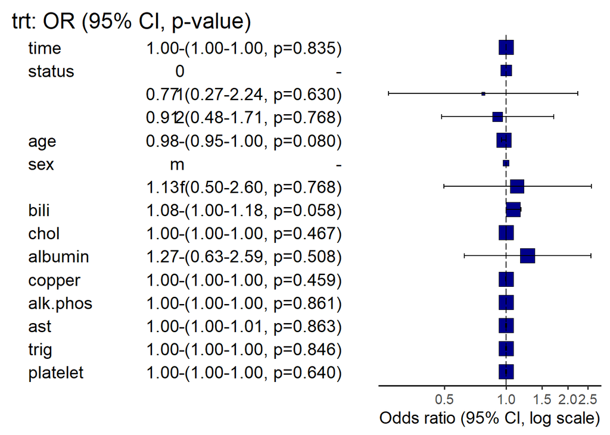

```r
explanatory = c("time", "status", "age", "sex", "bili", "chol", "albumin", "copper", "alk.phos",
          "ast", "trig", "platelet")
dependent = 'trt'


ds %>% or_plot(dependent, explanatory)
```